# Direct Cardiac Reprogramming, Stone et al., 2019, Analysis

### Brief Description

In this notebook, we document the analysis of direct cardiac analysis from Stone et al., 2019, charting the time course progression during this reporgramming process. We use this dataset to showcase application of Capybara to demonstrate the utility of transition scores. In this notebook file, we start with previous outcomes from running each step. The Stone et al dataset was processed through standard Seurat V4 pipeline with SCTransform to generate the UMAP embedding and their expression plots.

For details of the dataset, please refer to the Stone paper here (https://www.cell.com/cell-stem-cell/fulltext/S1934-5909(19)30276-0?_returnURL=https%3A%2F%2Flinkinghub.elsevier.com%2Fretrieve%2Fpii%2FS1934590919302760%3Fshowall%3Dtrue). For details of Capybara, please refer to the Capybara paper here (https://www.sciencedirect.com/science/article/pii/S1934590922000996?dgcid=coauthor).

### Load packages

```r
library(Capybara)
library(ggplot2)
```

### Previous Implementation Outcomes

Here we load the previous results from the intermediate folders.

1. We start with the bulk tissue selection. We generated the QP scores for the Stone et al. data against the bulk tissue profile, comparing this with the MCA background, leading us to select the most relevant tissues.

```r
background.mca <- readRDS("~/Desktop/Reproducibility/Figure 4/Intermediates/Stone et al Bulk Data/mca_bulk_background.Rds")
qp.paga.rslt.sub <- readRDS("~/Desktop/Reproducibility/Figure 4/Intermediates/Stone et al Bulk Data/stone_Data_bulk_mtx.Rds")

background.mtx <- background.mca[[2]]
mtx.test <- qp.paga.rslt.sub[,colnames(background.mtx)]

### cor test
ref.test <- t(background.mca$full.set)
mtx.test.cor <- t(qp.paga.rslt.sub)
corr.mtx <- WGCNA::cor(ref.test, mtx.test.cor)

correlation.cutoff <- quantile(corr.mtx, 0.90)

new.corr.bin <- corr.mtx
new.corr.bin[which(new.corr.bin >= correlation.cutoff)] <- 1
new.corr.bin[which(new.corr.bin < correlation.cutoff)] <- 0
new.corr.bin <- as.data.frame(new.corr.bin)

new.corr.bin$cell.bc.ref <- rownames(new.corr.bin)
new.corr.bin.melt <- reshape2::melt(new.corr.bin)
new.corr.bin.melt.sub <- new.corr.bin.melt[which(new.corr.bin.melt$value > 0),]
new.corr.bin.melt.sub$cell.type <- unlist(lapply(strsplit(new.corr.bin.melt.sub$cell.bc.ref, "_"), function(x) x[1]))

cell.types.in.bulk.class <- as.data.frame(table(new.corr.bin.melt.sub$cell.type))
cell.types.in.bulk.class$perc <- round(cell.types.in.bulk.class$Freq * 100/sum(cell.types.in.bulk.class$Freq), digits = 3)

count.in.cat <- c()
unique.cat <- unique(unlist(lapply(strsplit(rownames(new.corr.bin), "_"), function(x) x[1])))
for (uc in unique.cat) {
  curr.subset <- new.corr.bin[which(startsWith(rownames(new.corr.bin), uc)), c(1:30729)]
  count.in.cat[uc] <- sum(colSums(curr.subset) >= nrow(curr.subset) * 0.80)
}

count.in.cat <- as.data.frame(count.in.cat)
count.in.cat$perc <- round(count.in.cat$count.in.cat *100/sum(count.in.cat$count.in.cat), digits = 3)

final.cell.types.fetal <- rownames(count.in.cat)[which(count.in.cat$count.in.cat > 100)]

comp.raw <- count.in.cat
comp.raw <- comp.raw[order(-comp.raw$perc), ]
comp.raw$Var1 <- rownames(comp.raw)
comp.raw$Var1 <- factor(comp.raw$Var1, comp.raw$Var1, ordered = T)

comp.raw$label <- "Cardiac Reprogramming"
```

Here we look at the distributions of the different tissues types involved

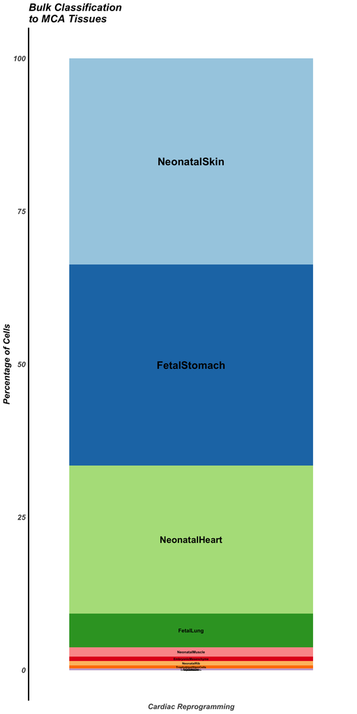

```r
ggplot(comp.raw, aes(x = comp.raw$label, y = comp.raw$perc, fill = comp.raw$Var1, label = comp.raw$Var1)) +
  geom_bar(stat = "identity") +
  geom_text(position = position_stack(vjust = 0.5), fontface = "bold", aes(size = comp.raw$perc)) +
  scale_fill_manual(
    name = "Mapped MCA Tissue",
    values = c(RColorBrewer::brewer.pal(12, "Paired"),
               RColorBrewer::brewer.pal(8, "Set2"))
  ) +
  labs(y = "Percentage of Cells") +
  ggtitle("Bulk Classification \nto MCA Tissues") +
  theme(legend.position = "none",
        axis.ticks = element_blank(),
        axis.title.x = element_blank(),
        axis.text = element_text(face = "bold.italic", size = 12),
        title = element_text(face = "bold.italic", size = 14),
        panel.grid.major = element_blank(),
        panel.grid.minor = element_blank(),
        panel.background = element_blank(),
        axis.line.x = element_blank(),
        axis.line.y = element_line(color = "black", size =1))
```

2. Construction of the high-resolution single-cell reference based on the MCA data. To run from scratch, please order and download the MCA data as recommended in the GitHub repo.
1. First we collect the counts from the MCA with meta data.

```r
mca <- read.csv("~/Box Sync/Morris Lab/Classifier Analysis/Reference datasets/MCA/MCA_CellAssignments.csv",
                row.names = 1, header = T, stringsAsFactors = F)
mca.meta <- data.frame(row.names = mca$Cell.name,
                       tissue = mca$Tissue,
                       cell.bc.tissue = unlist(lapply(strsplit(mca$Cell.name, "_"), function(x) x[1])),
                       cell.type = mca$Annotation,
                       stringsAsFactors = F)

final.cell.types.fetal <- c("NeonatalSkin", "FetalStomach", "NeonatalHeart", "FetalLung")

cardiac.rp.all.meta <- mca.meta[which(mca.meta$cell.bc.tissue %in% final.cell.types.fetal), ]

mca.counts.all.involved <- NULL
tissues.to.read <- unique(cardiac.rp.all.meta$tissue)
general.path <- "~/Box Sync/Morris Lab/Classifier Analysis/Reference datasets/MCA/MCA_Counts/"
for (i in 1:length(tissues.to.read)) {
  curr.t <- tissues.to.read[i]
  curr.path.to.read <- paste0(general.path, curr.t, "/count.csv")
  curr.count <- read.csv(curr.path.to.read, header = T, row.names = 1, stringsAsFactors = F)
  if (is.null(mca.counts.all.involved)) {
    mca.counts.all.involved <- curr.count
  } else {
    mca.counts.all.involved <- cbind(mca.counts.all.involved, curr.count)
  }
}

cardiac.rp.all.meta$cell.type.1 <- gsub("\\([^)]*\\)", "", cardiac.rp.all.meta$cell.type)
cardiac.rp.all.meta$cell.type.alone <- unlist(lapply(strsplit(cardiac.rp.all.meta$cell.type.1, "_"), function(x) x[1]))

cell.type.tissue.freq <- table(cardiac.rp.all.meta$cell.type.alone, cardiac.rp.all.meta$tissue)
cell.type.tissue.freq.bin <- cell.type.tissue.freq
cell.type.tissue.freq.bin[which(cell.type.tissue.freq.bin > 0)] <- 1
cell.type.expand <- as.data.frame(sort(rowSums(cell.type.tissue.freq.bin))/ncol(cell.type.tissue.freq.bin))

cell.type.expand.less.than.100 <- rownames(cell.type.expand)

cardiac.rp.all.meta.sub <- cardiac.rp.all.meta[which(cardiac.rp.all.meta$cell.type.alone %in% cell.type.expand.less.than.100), ]
mca.counts.all.involved.sub <- mca.counts.all.involved[,rownames(cardiac.rp.all.meta.sub)]

cardiac.rp.all.meta.sub$cell.type.1 <- tolower(cardiac.rp.all.meta.sub$cell.type.1)
coldata.df <- cardiac.rp.all.meta.sub
ct.freq.raw <- as.data.frame(table(coldata.df$cell.type.1), stringsAsFactors = F)
ct.freq <- ct.freq.raw[which(ct.freq.raw$Freq >= 30), ]

coldata.df <- coldata.df[which(coldata.df$cell.type.1 %in% as.character(ct.freq$Var1)), ]
coldata.df$cell.type.1 <- gsub(" ", ".", coldata.df$cell.type.1)
```

2. Reference establishment

```r
ref.list <- construct.high.res.reference(ref.mtx = mca.counts.all.involved.sub, coldata.df = coldata.df,
                                         criteria = "cell.type.1")
```

```r
ref.list <- readRDS("~/Desktop/Reproducibility/Figure 4/Intermediates/Stone et al References/reference_data.Rds")
ref.sc <- ref.list[[1]]
ref.meta <- ref.list[[2]]
ref.df <- ref.list[[3]]
```

3. Quadratic programming outcomes

```r
background.mtx <- read.csv("~/Desktop/Reproducibility/Figure 4/Intermediates/Stone et al QP Outcomes/01_stone_et_al_ref_scale.csv", header = T, row.names = 1, stringsAsFactors = F)

mtx.test <- read.csv("~/Desktop/Reproducibility/Figure 4/Intermediates/Stone et al QP Outcomes/01_stone_et_al_test_scale.csv", header = T, row.names = 1, stringsAsFactors = F)
```

4. Initial Classification and its breakdown

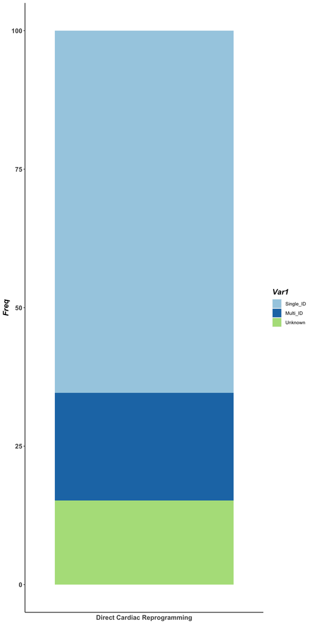

```r
init.class <- read.csv("~/Desktop/Reproducibility/Figure 4/Intermediates/Stone et al Initial Classification/initial_class.csv", row.names = 1, stringsAsFactors = F, header = T)

freq.table <- as.data.frame(table(init.class$init.class) * 100/sum(table(init.class$init.class)))
freq.table <- freq.table[order(freq.table$Freq, decreasing = T), ]
freq.table$Var1 <- factor(as.character(freq.table$Var1),
                          levels = as.character(freq.table$Var1),
                          ordered = T)

ggplot(freq.table, aes(x = "Direct Cardiac Reprogramming", y = Freq, fill = Var1)) +
  geom_bar(position = "stack", stat = "identity") +
  scale_fill_brewer(palette = "Paired") +
  theme(legend.position = "right",
        axis.text.x = element_text(face = "bold", size = 12),
        axis.text.y = element_text(face = "bold", size = 12),
        axis.title.x = element_blank(),
        axis.title.y = element_text(face = "bold.italic", size = 14),
        panel.grid.major = element_blank(),
        panel.grid.minor = element_blank(),
        panel.background = element_blank(),
        title = element_text(face = "bold.italic", size = 14),
        axis.line = element_line(colour = "black"),
        axis.ticks.x = element_blank())
```

5. Empirical p-value results

```r
ref.perc.list <- readRDS("~/Desktop/Reproducibility/Figure 4/Intermediates/Stone et al Permutation Results/ref_permutation_list.Rds")
perc.list <- readRDS("~/Desktop/Reproducibility/Figure 4/Intermediates/Stone et al Permutation Results/sample_permutation_list.Rds")
```

6. Binarization counts

```r
bin.count <- readRDS("~/Desktop/Reproducibility/Figure 4/Intermediates/Stone et al Binarization and Classification/binarized_counts.Rds")
```

7. Classification

```r
classification <- readRDS("~/Desktop/Reproducibility/Figure 4/Intermediates/Stone et al Binarization and Classification/classification_outcome.Rds")
colnames(classification)[4] <- "tissue"
```

8. We re-evaluate tissue relevance after high-resolution reference classification

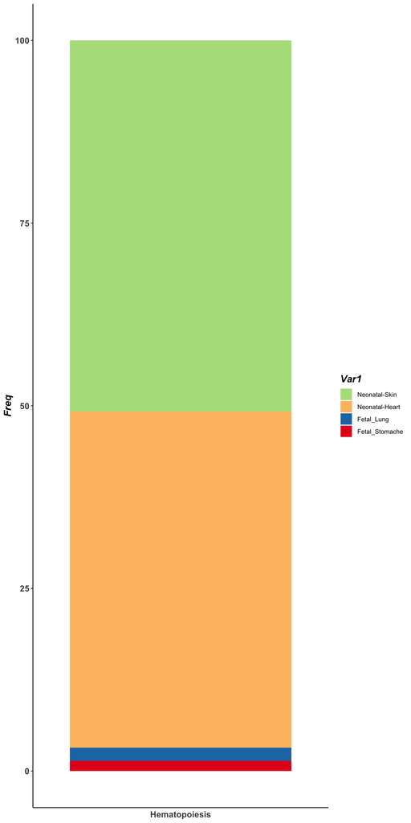

```r
freq.table <- as.data.frame(table(classification$tissue) * 100/sum(table(classification$tissue)))
freq.table <- freq.table[order(freq.table$Freq, decreasing = T), ]
freq.table$Var1 <- factor(as.character(freq.table$Var1),
                          levels = as.character(freq.table$Var1),
                          ordered = T)

freq.table$color <- c(RColorBrewer::brewer.pal(12, "Paired")[3],
                      RColorBrewer::brewer.pal(12, "Paired")[7],
                      RColorBrewer::brewer.pal(12, "Paired")[2],
                      RColorBrewer::brewer.pal(12, "Paired")[6])

ggplot(freq.table, aes(x = "Hematopoiesis", y = Freq, fill = Var1)) +
  geom_bar(position = "stack", stat = "identity") +
  scale_fill_manual(values = freq.table$color) +
  theme(legend.position = "right",
        axis.text.x = element_text(face = "bold", size = 12),
        axis.text.y = element_text(face = "bold", size = 12),
        axis.title.x = element_blank(),
        axis.title.y = element_text(face = "bold.italic", size = 14),
        panel.grid.major = element_blank(),
        panel.grid.minor = element_blank(),
        panel.background = element_blank(),
        title = element_text(face = "bold.italic", size = 14),
        axis.line = element_line(colour = "black"),
        axis.ticks.x = element_blank())
```

### Load UMAP Embedding of the data

1. Assess the overall distribution of cells across different timepoints

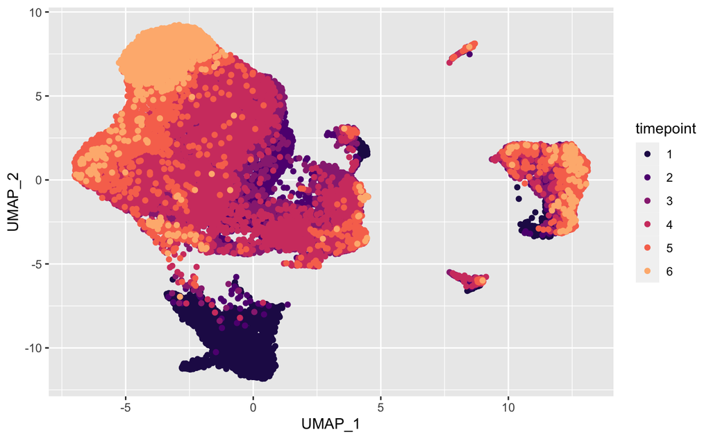

```r
umap.embedding <- readRDS("~/Desktop/Reproducibility/Figure 4/Intermediates/Stone et al UMAP/umap_embedding.Rds")
umap.embedding$timepoint <- unlist(lapply(strsplit(rownames(umap.embedding), "[.]"), function(x) x[2]))
ggplot(umap.embedding, aes(x = UMAP_1, y = UMAP_2, color = timepoint)) +
  geom_point() +
  scale_color_viridis_d(option = "A", begin = 0.15, end = 0.85)
```

2. We merge the detailed classification in bigger groups to look at different major populations.

```r
umap.embedding$capy.call <- classification[rownames(umap.embedding), "call"]
umap.embedding$more.general.capy.call <- umap.embedding$capy.call
umap.embedding$more.general.capy.call[which(startsWith(umap.embedding$more.general.capy.call, "macrophage"))] <- "Blood"
umap.embedding$more.general.capy.call[which(startsWith(umap.embedding$more.general.capy.call, "erythroblast"))] <- "Blood"
umap.embedding$more.general.capy.call[which(startsWith(umap.embedding$more.general.capy.call, "dendritic.cell"))] <- "Blood"
umap.embedding$more.general.capy.call[which(startsWith(umap.embedding$more.general.capy.call, "mast.cell"))] <- "Blood"
umap.embedding$more.general.capy.call[which(startsWith(umap.embedding$more.general.capy.call, "neutrophil"))] <- "Blood"

umap.embedding$more.general.capy.call[which(startsWith(umap.embedding$more.general.capy.call, "muscle.cell"))] <- "Muscle"
umap.embedding$more.general.capy.call[which(startsWith(umap.embedding$more.general.capy.call, "smooth.muscle.cell"))] <- "Muscle"

umap.embedding$more.general.capy.call[which(startsWith(umap.embedding$more.general.capy.call, "stromal.cell"))] <- "Stromal Cell"

umap.embedding$more.general.capy.call[which(umap.embedding$more.general.capy.call %in% c("endothelial.cell", "brown.adipose.tissue_cidea.high", "osteoblast_ppic.high", "keratinocyte", "epithelial.cell", "adipocyte", "dividing.cell", "neuron", "melanocyte",  "epithelial.cell_aldh1a2_high","acinar.cell_ctrb1.high", "endothelial.cell_igfbp5.high", "vascular.endothelial.cell"))] <- "Other"

umap.embedding$more.general.capy.call[which(startsWith(umap.embedding$more.general.capy.call, "atrial.cardiomyocyte"))] <- "Atrial"
umap.embedding$more.general.capy.call[which(startsWith(umap.embedding$more.general.capy.call, "left.ventricle"))] <- "Ventricular"
```

3. Here we will assess the overall distribution of cell types across time points.

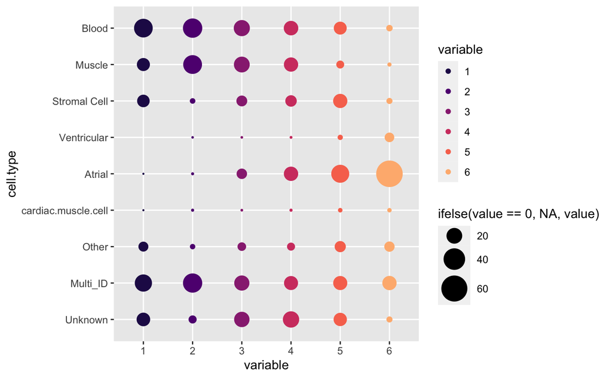

```r
freq.table <- as.data.frame(apply(table(umap.embedding$more.general.capy.call, umap.embedding$timepoint), 2, function(x) x*100/sum(x)))
freq.table$cell.type <- rownames(freq.table)
freq.table.melt <- reshape2::melt(freq.table)
freq.table.melt$cell.type <- factor(freq.table.melt$cell.type,
                                    levels = rev(c("Blood", "Muscle", "Stromal Cell",
                                               "Ventricular", "Atrial", "cardiac.muscle.cell",
                                               "Other", "Multi_ID", "Unknown")),
                                    ordered = T)
ggplot(freq.table.melt, aes(x = variable, y = cell.type, color = variable, size = ifelse(value == 0, NA, value))) +
  geom_point() +
  scale_color_viridis_d(option = "A", begin = 0.15, end = 0.85) +
  scale_size_area(max_size = 10)
```

### Hybrid Population Evaluation

1. Identify the hybrid populations and filter based on QP scores. Note we use the term ‘multi-id’ to refer to hybrid cells.

```r
multi.classification.list <- multi.id.curate.qp(binary.counts = bin.count, classification = classification, qp.matrix = mtx.test)
# Reassign variables
actual.multi <- multi.classification.list[[1]]
new.classification <- multi.classification.list[[2]]

actual.multi.merge <- data.frame()
cells.multi <- unique(actual.multi$cell.bc)

for (cm in cells.multi) {
  curr.ct.comb <- actual.multi[which(actual.multi$cell.bc == cm),]
  curr.ct.combination <- gsub("frxn_cell.type_", "", as.character(curr.ct.comb$variable))
  #curr.ct.combination <- sort(unique(unlist(lapply(strsplit(curr.ct.combination, "_"), function(x) x[[1]]))))
  if (length(curr.ct.combination) > 1) {
    curr.df <- data.frame(barcode = cm, ct.comb = paste0(curr.ct.combination, collapse = "-"), stringsAsFactors = F)

    if (nrow(actual.multi.merge) <= 0) {
      actual.multi.merge <- curr.df
    } else {
      actual.multi.merge <- rbind(actual.multi.merge, curr.df)
    }
  }
}

actual.multi.merge$tp <- unlist(lapply(strsplit(actual.multi.merge$barcode, "[.]"), function(x) x[2]))
```

2. Filter the hybrid cells based on frequency. The frequency is determined as 0.5% of the number of cells at each day, as listed below.

```r
actual.multi.merge$day <- actual.multi.merge$tp
actual.multi.merge$day[which(actual.multi.merge$day == 1)] <- "Day -1"
actual.multi.merge$day[which(actual.multi.merge$day == 2)] <- "Day 1"
actual.multi.merge$day[which(actual.multi.merge$day == 3)] <- "Day 2"
actual.multi.merge$day[which(actual.multi.merge$day == 4)] <- "Day 3"
actual.multi.merge$day[which(actual.multi.merge$day == 5)] <- "Day 7"
actual.multi.merge$day[which(actual.multi.merge$day == 6)] <- "Day 14"

significant.trans <- unique(
  c(names(which(table(actual.multi.merge$ct.comb[which(actual.multi.merge$day == "Day 14")]) > 12)),
    names(which(table(actual.multi.merge$ct.comb[which(actual.multi.merge$day == "Day -1")]) > 21)),
    names(which(table(actual.multi.merge$ct.comb[which(actual.multi.merge$day == "Day 1")]) > 18)),
    names(which(table(actual.multi.merge$ct.comb[which(actual.multi.merge$day == "Day 2")]) > 45)),
    names(which(table(actual.multi.merge$ct.comb[which(actual.multi.merge$day == "Day 3")]) > 37)),
    names(which(table(actual.multi.merge$ct.comb[which(actual.multi.merge$day == "Day 7")]) > 22))))
significant.ones <- actual.multi.merge[which(actual.multi.merge$ct.comb %in% significant.trans), ]
two.hybrids.only <- unlist(lapply(strsplit(significant.ones$ct.comb, "-"), function(x) length(x) == 2))
significant.ones.sub <- significant.ones[two.hybrids.only,]

multi <- table(significant.ones.sub$ct.comb, significant.ones.sub$day)
```

3. Calculate hybrid cell frequencies across days

```r
multi <- as.data.frame(apply(multi, 2, function(x) round(x*100/sum(x), digits = 3)))
multi$hybrid.label <- rownames(multi)

multi.melt <- reshape2::melt(multi)
multi.ordered <- multi[order(-multi$`Day 14`),]
multi.ordered$hybrid.label <- factor(multi.ordered$hybrid.label, levels = multi.ordered$hybrid.label, ordered = T)

multi.melt.ordered <- reshape2::melt(multi.ordered)
```

Plot hybrid frequencies across different time points

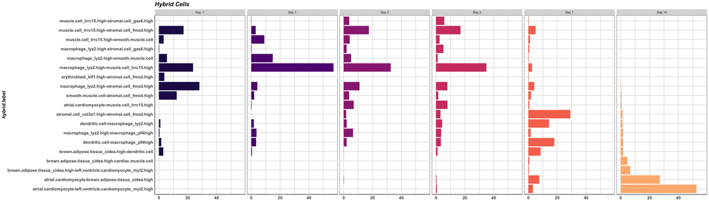

```r
multi.melt.ordered$variable <- factor(multi.melt.ordered$variable,
                                      levels = c("Day -1", "Day 1", "Day 2", "Day 3", "Day 7", "Day 14"),
                                      ordered = T)
ggplot(multi.melt.ordered, aes(x = hybrid.label, y = value, fill = variable)) +
  geom_bar(stat = "identity", position = "dodge")+
  coord_flip() +
  scale_fill_viridis_d(option = "A", begin = 0.15, end = 0.85) +
  labs(y = "Percentage Composition") +
  facet_grid(.~variable) +
  ggtitle("Hybrid Cells") +
  theme(legend.position = "none",
        axis.text.x = element_text(face = "bold", size = 12),
        axis.text.y = element_text(face = "bold", size = 12),
        axis.title.x = element_blank(),
        axis.title.y = element_text(face = "bold.italic", size = 14),
        panel.grid.major = element_line(color = "lightgrey", size = 0.5),
        panel.grid.minor = element_line(color = "lightgrey", size = 0.5),
        panel.background = element_rect(color = "black", fill = "white"),
        title = element_text(face = "bold.italic", size = 14),
        axis.line = element_line(colour = "black"),
        axis.ticks = element_blank())
```

4. Here we focus on the hybrid population on Day 14.

```r
multi.d14 <- multi[which(multi$`Day 14` > 0), ]
multi.d14.ordered <- multi.d14[order(-multi.d14$`Day 14`), ]
multi.d14.ordered$hybrid.label <- factor(multi.d14.ordered$hybrid.label, levels = multi.d14.ordered$hybrid.label, ordered = T)
```

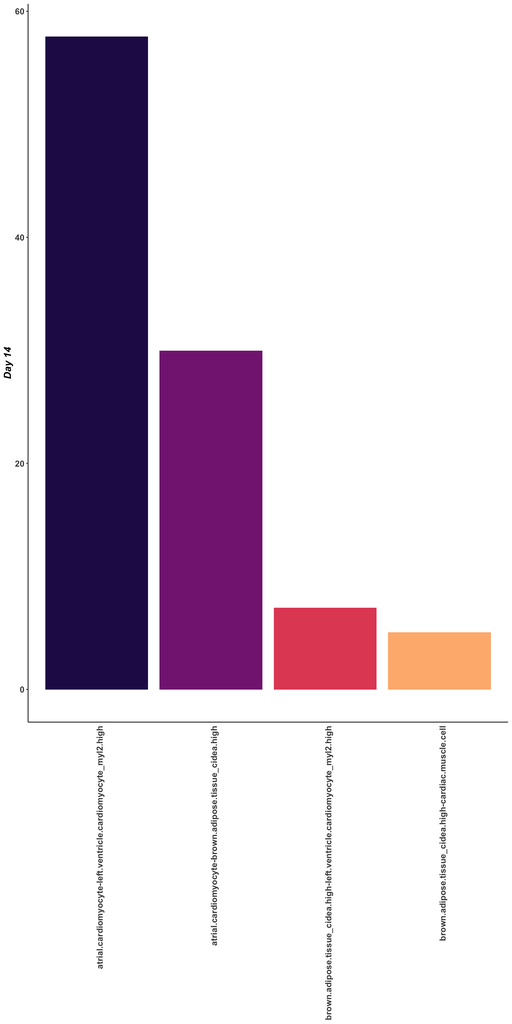

```r
multi.d14.ordered.sub <- multi.d14.ordered[,c(3,7)]
multi.d14.ordered.sub <- multi.d14.ordered.sub[-which(multi.d14.ordered.sub$`Day 14` < 2), ]
multi.d14.ordered.sub$`Day 14` <- multi.d14.ordered.sub$`Day 14` * 100/sum(multi.d14.ordered.sub$`Day 14`)

ggplot(multi.d14.ordered.sub, aes(x = hybrid.label, y = `Day 14`, fill = hybrid.label)) +
  geom_bar(position = "dodge", stat = "identity") +
  scale_fill_viridis_d(option = "A", begin = 0.15, end = 0.85) +
  theme(legend.position = "none",
        axis.text.x = element_text(face = "bold", size = 12, angle = 90, hjust = 1),
        axis.text.y = element_text(face = "bold", size = 12),
        axis.title.x = element_blank(),
        axis.title.y = element_text(face = "bold.italic", size = 14),
        panel.grid.major = element_blank(),
        panel.grid.minor = element_blank(),
        panel.background = element_blank(),
        title = element_text(face = "bold.italic", size = 14),
        axis.line = element_line(colour = "black"),
        axis.ticks.x = element_blank())
```

5. Here we project the classified cardiomyocytes and the major hybrid population on the UMAP embedding.

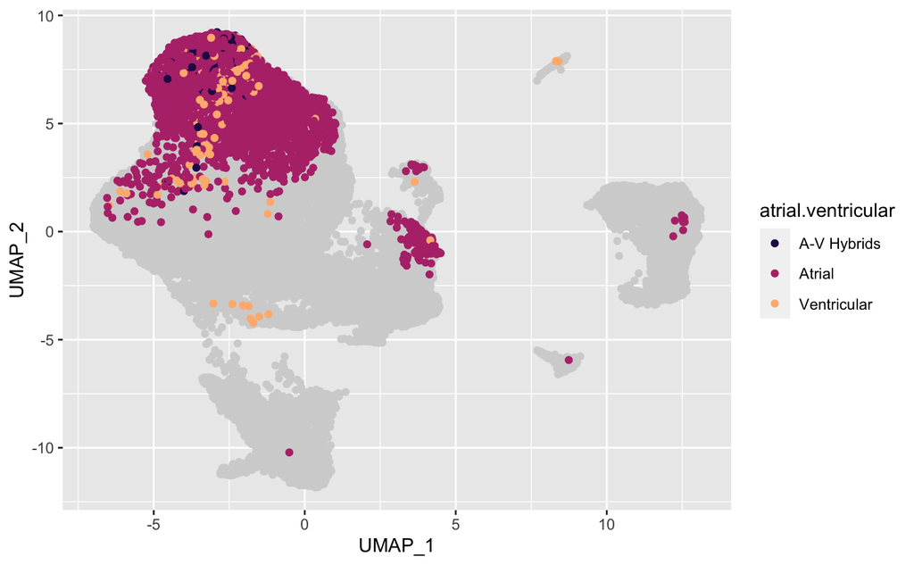

```r
umap.embedding$atrial.ventricular <- NA
umap.embedding$atrial.ventricular[which(startsWith(umap.embedding$capy.call,"atrial.cardiomyocyte"))] <- "Atrial"
umap.embedding$atrial.ventricular[which(startsWith(umap.embedding$capy.call,"left.ventricle.cardiomyocyte"))] <- "Ventricular"
av.hybrids <- actual.multi.merge[which(actual.multi.merge$ct.comb %in% c("atrial.cardiomyocyte_acta2.high-left.ventricle.cardiomyocyte_myl2.high", "atrial.cardiomyocyte-left.ventricle.cardiomyocyte_myl2.high")), "barcode"]
umap.embedding[av.hybrids, "atrial.ventricular"] <- "A-V Hybrids"

ggplot(umap.embedding, aes(x = UMAP_1, y = UMAP_2)) +
  geom_point(color = "lightgrey") +
  geom_point(data = umap.embedding[which(!is.na(umap.embedding$atrial.ventricular)), ], aes(color = atrial.ventricular)) +
  scale_color_viridis_d(option = "A", begin = 0.15, end = 0.85)
```

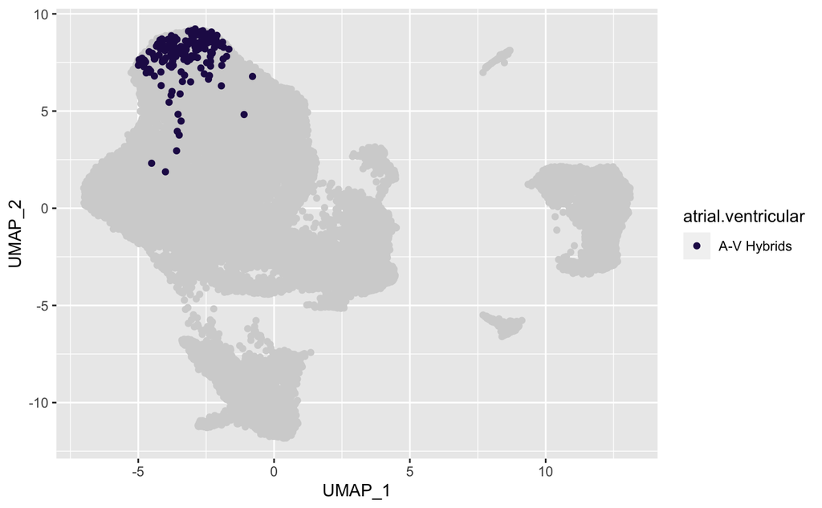

```r
ggplot(umap.embedding, aes(x = UMAP_1, y = UMAP_2)) +
  geom_point(color = "lightgrey") +
  geom_point(data = umap.embedding[which(umap.embedding$atrial.ventricular == "A-V Hybrids"), ], aes(color = atrial.ventricular)) +
  scale_color_viridis_d(option = "A", begin = 0.15, end = 0.85)
```

### Calculate Transition Scores

1. Here we calculate transition scores based on the identified hybrid cells.

```r
score.df <- transition.score(actual.multi)
```

2. We put the scores with the umap and project it on the umap

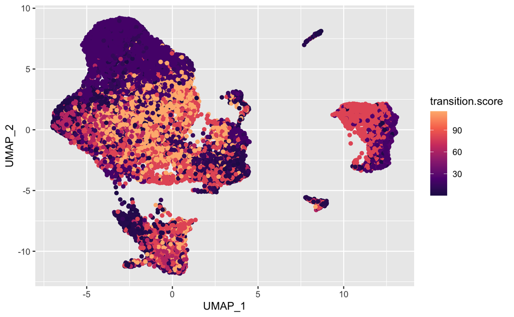

```r
umap.embedding$transition.score <- score.df[umap.embedding$capy.call, "entropy"]

ggplot(umap.embedding[-which(is.na(umap.embedding$transition.score)),], aes(x = UMAP_1, y = UMAP_2, color = transition.score)) +
  geom_point() +
  scale_color_viridis_c(option = "A", begin = 0.15, end = 0.85)
```

3. We plot the transition scores in violin plot across the different timepoints

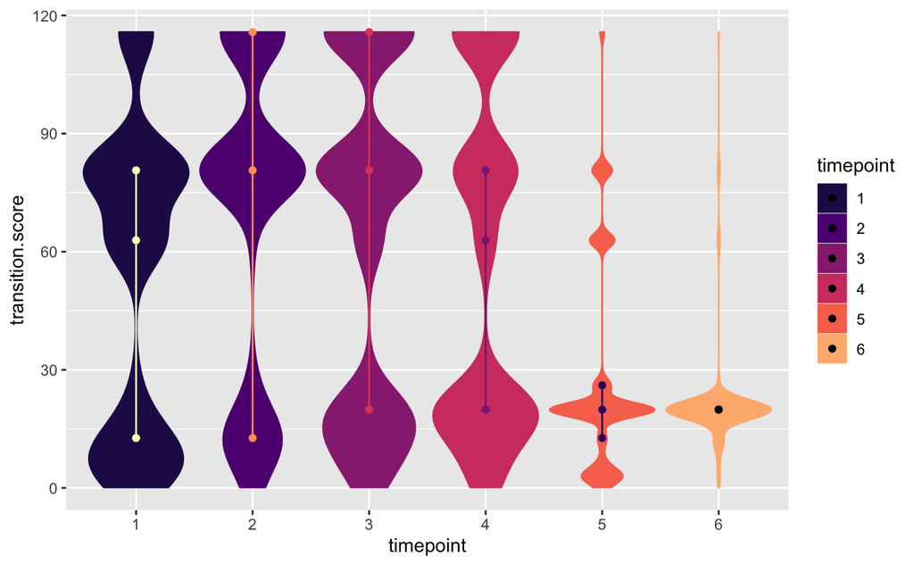

```r
## Ref: https://stackoverflow.com/questions/17319487/median-and-quartile-on-violin-plots-in-ggplot2
median.quartile <- function(x){
  out <- quantile(x, probs = c(0.25,0.5,0.75))
  names(out) <- c("ymin","y","ymax")
  return(out)
}

ggplot(umap.embedding[-which(is.na(umap.embedding$transition.score)),], aes(x = timepoint, y = transition.score, fill = timepoint, color = timepoint)) +
  geom_violin(scale = "width") +
  stat_summary(fun.y=median.quartile,geom='point', color = rep(rev(viridis(6, option = "A")), each = 3)) +
  stat_summary(fun.y=median.quartile,geom='line', color = rep(rev(viridis(6, option = "A")), each = 3)) +
  scale_fill_viridis_d(option = "A", begin = 0.15, end = 0.85) +
  scale_color_viridis_d(option = "A", begin = 0.15, end = 0.85)
```

Overall, we showcase the application of Capybara in another continuous biological system and demonstrate the utility of transition scores. Specifically, the transition scores here show a significant increase in the first 2 days, mirroring previous findings that reprogmamming outcome is largely determined within this initial 48 hr. In addition, we identified a significant hybrid population on day 14 between atrial and ventricular cardiomyocytes. We further validated these cells using RNA FISH and Immunostaining.